# The Most Dangerous and Costly Weather Events in the United States

Grayson Udstrand

# Synopsis

This study was intended to use NOAA weather event data to find out which types of weather events are the most costly in terms of (1) human safety in America and (2) monetary data. The data was programmatically pulled, cleaned, processed, and analyzed using R to find evidence supporting potential answers to the above directive. The final results show that there are clear and potent leaers in both of these aforementioned categories: heat waves and hurricanes/typhoons, respectively. There is, however, cause to think that there may be more work to be done in the future due to some distrubing results with the final output of the analysis.

# Data Processing

## Loading

```r
# If compressed data file does not exist, download it
if (!file.exists("StormData.csv.bz2")) {
    download.file("https://d396qusza40orc.cloudfront.net/repdata%2Fdata%2FStormData.csv.bz2",
                   destfile = "StormData.csv.bz2")
}
StormData <- read.csv("StormData.csv.bz2", header = TRUE)

# Take a look at the headers and data types to see what we need
str(StormData)
```

```
## 'data.frame':    902297 obs. of  37 variables:
##  $ STATE__   : num  1 1 1 1 1 1 1 1 1 1 ...
##  $ BGN_DATE  : Factor w/ 16335 levels "1/1/1966 0:00:00",..: 6523 6523 4242 11116 2224 2224 2260 383 3980 3980 ...
##  $ BGN_TIME  : Factor w/ 3608 levels "00:00:00 AM",..: 272 287 2705 1683 2584 3186 242 1683 3186 3186 ...
##  $ TIME_ZONE : Factor w/ 22 levels "ADT","AKS","AST",..: 7 7 7 7 7 7 7 7 7 7 ...
##  $ COUNTY    : num  97 3 57 89 43 77 9 123 125 57 ...
##  $ COUNTYNAME: Factor w/ 29601 levels "","5NM E OF MACKINAC BRIDGE TO PRESQUE ISLE LT MI",..: 13513 1873 4598 10592 4372 10094 1973 23873 24418 4598 ...
##  $ STATE     : Factor w/ 72 levels "AK","AL","AM",..: 2 2 2 2 2 2 2 2 2 2 ...
##  $ EVTYPE    : Factor w/ 985 levels "   HIGH SURF ADVISORY",..: 834 834 834 834 834 834 834 834 834 834 ...
##  $ BGN_RANGE : num  0 0 0 0 0 0 0 0 0 0 ...
##  $ BGN_AZI   : Factor w/ 35 levels "","  N"," NW",..: 1 1 1 1 1 1 1 1 1 1 ...
##  $ BGN_LOCATI: Factor w/ 54429 levels ""," Christiansburg",..: 1 1 1 1 1 1 1 1 1 1 ...
##  $ END_DATE  : Factor w/ 6663 levels "","1/1/1993 0:00:00",..: 1 1 1 1 1 1 1 1 1 1 ...
##  $ END_TIME  : Factor w/ 3647 levels ""," 0900CST",..: 1 1 1 1 1 1 1 1 1 1 ...
##  $ COUNTY_END: num  0 0 0 0 0 0 0 0 0 0 ...
```

[output cut: 23 more lines]

## Preprocessing

For this analysis we will be only analyzing data from January 1996 on forward since this is the most complete data according to NOAA. Since we are targeting information on the most dangerous and costly weather events, we want all information available on both human and financial costs of the different weather types.

All of this in mind, we know we will need date information to filter the data by date range plus all information available for injuries, fatalities, property, and crop damage. Additionally, to calculate the actual number for these property and crop damages, we take in the respective multiplier columns which are used to calculate the costs.

```r
# Load useful libraries
library(dplyr)
library(lubridate)

StormDataLess <- select(StormData,
                        BGN_DATE,
                        EVTYPE,
                        FATALITIES,
                        INJURIES,
                        PROPDMG,
                        PROPDMGEXP,
                        CROPDMG,
                        CROPDMGEXP)

# Convert the date column from factor to a date
StormDataLess <- mutate(StormDataLess, BGN_DATE = as.Date(BGN_DATE, format = "%m/%d/%Y"))

# Filter out the data which does not log all event types
StormDataLess <- filter(StormDataLess, year(BGN_DATE) >= 1996)
```

In order to calculate the correct cost in the PROPDMG and CROPDMG columns, we implement the findings of [this publication](https://rstudio-pubs-static.s3.amazonaws.com/58957_37b6723ee52b455990e149edde45e5b6.html). The converison scales are not immediately obvious, so it is wise to look over this Rpub to understand why the next chunk is correct.

```r
# Implement the conversion mechanism
StormDataLessEXP <- mutate(StormDataLess,
        PROPDMG = ifelse(PROPDMGEXP == "H" | PROPDMGEXP == "h", PROPDMG * 100,
                  ifelse(PROPDMGEXP == "K" | PROPDMGEXP == "k", PROPDMG * 1000,
                  ifelse(PROPDMGEXP == "M" | PROPDMGEXP == "m", PROPDMG * 1000000,
                  ifelse(PROPDMGEXP == "B" | PROPDMGEXP == "b", PROPDMG * 1000000000,
                  ifelse(PROPDMGEXP == "+", PROPDMG,
                  ifelse(PROPDMGEXP == "?" | PROPDMGEXP == "-", 0,
                  ifelse(PROPDMGEXP == "0" |
                         PROPDMGEXP == "1" |
                         PROPDMGEXP == "2" |
                         PROPDMGEXP == "3" |
                         PROPDMGEXP == "4" |
                         PROPDMGEXP == "5" |
                         PROPDMGEXP == "6" |
                         PROPDMGEXP == "7" |
                         PROPDMGEXP == "8", PROPDMG * 10, PROPDMG))))))))

StormDataLessEXP <- mutate(StormDataLessEXP,
        CROPDMG = ifelse(CROPDMGEXP == "H" | CROPDMGEXP == "h", CROPDMG * 100,
                  ifelse(CROPDMGEXP == "K" | CROPDMGEXP == "k", CROPDMG * 1000,
                  ifelse(CROPDMGEXP == "M" | CROPDMGEXP == "m", CROPDMG * 1000000,
                  ifelse(CROPDMGEXP == "B" | CROPDMGEXP == "b", CROPDMG * 1000000000,
                  ifelse(CROPDMGEXP == "+", CROPDMG,
                  ifelse(CROPDMGEXP == "?" | CROPDMGEXP == "-", 0,
                  ifelse(CROPDMGEXP == "0" |
                         CROPDMGEXP == "1" |
                         CROPDMGEXP == "2" |
                         CROPDMGEXP == "3" |
                         CROPDMGEXP == "4" |
                         CROPDMGEXP == "5" |
                         CROPDMGEXP == "6" |
                         CROPDMGEXP == "7" |
                         CROPDMGEXP == "8", CROPDMG * 10, CROPDMG))))))))

# Drop unnecessary columns
StormDataClean <- select(StormDataLessEXP, -one_of(c("PROPDMGEXP", "CROPDMGEXP")))
```

At this point we can calculate the total damages in both human life and property and crop damage. We add these columns to the clean dataset create as columns so that we may work with them. The transformation for the actual monetary cost columns should make sense, but the human cost column sum might be a little more questionable. The line of thinking was that fatalities are obviously more costly than injuries. However, there is no way to effectively quantify the factor by which a fatality is worse than injury, especially given the vague nature of the definition of “injury” (these may range from paper-cuts to total paralysis for all we know). Therefore, we keep it simple by just adding together the number of fatalities and injuries by row to get total human cost of the event.

```r
library(dplyr)

# Add the cost columns and filter out those events where the cost is 0
StormDataClean <- mutate(StormDataClean, HumanCost = FATALITIES + INJURIES)
StormDataClean <- mutate(StormDataClean, DamageCost = PROPDMG + CROPDMG)
```

## Analysis

At this point we are ready to begin our analysis on event types. We do this by creating two aggregate tables that find the mean cost per event for each event. This metric is valuable as it lends us the ability to figure out which events as a class are most costly. The original thought was to use the sum of the costs to present the costliest event type, but this poses potentially two problems:

1. This metric is more dependent on all events in question being recorded properly and
2. it puts more weight on events that occur far more often but may be less costly on a per-event basis

```r
# Find the most violent event types
EventHumanCost <- aggregate(data = StormDataClean, HumanCost ~ EVTYPE, mean)
EventPropertyCost <- aggregate(data = StormDataClean, DamageCost ~ EVTYPE, mean)

# Filter out the events with no cost
EventHumanCost <- filter(EventHumanCost, HumanCost > 0)
EventPropertyCost <- filter(EventPropertyCost, DamageCost > 0)

# Check over the numbers to see where to draw the line
summary(EventHumanCost$HumanCost)
```

```
##     Min.  1st Qu.   Median     Mean  3rd Qu.     Max.
##  0.00017  0.10570  0.39040  1.69700  1.00000 70.00000
```

```r
summary(EventPropertyCost$DamageCost)
```

```
##      Min.   1st Qu.    Median      Mean   3rd Qu.      Max.
##         2      5068     19850   7501000    242200 817200000
```

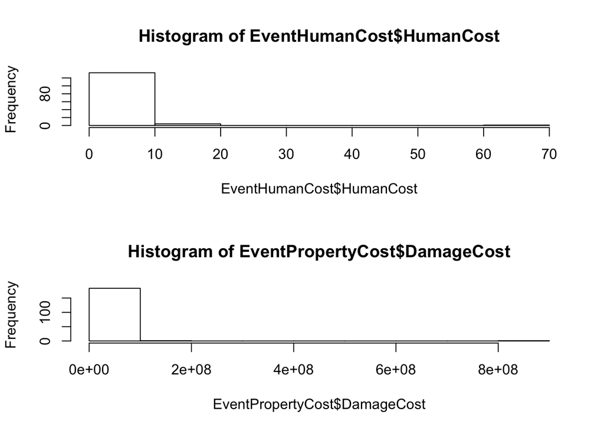

```r
par(mfrow = c(2,1))
hist(EventHumanCost$HumanCost)
hist(EventPropertyCost$DamageCost)
```

```r
EventHumanCost <- arrange(EventHumanCost, desc(HumanCost))
EventPropertyCost <- arrange(EventPropertyCost, desc(DamageCost))

head(EventHumanCost)
```

```
##               EVTYPE HumanCost
## 1          Heat Wave  70.00000
## 2  HURRICANE/TYPHOON  15.21591
## 3      COLD AND SNOW  14.00000
## 4 WINTER WEATHER MIX  11.33333
## 5              GLAZE  10.14286
## 6            TSUNAMI   8.10000
```

```r
head(EventPropertyCost)
```

```
##              EVTYPE DamageCost
## 1 HURRICANE/TYPHOON  817201282
## 2       STORM SURGE  170725458
## 3         HURRICANE   85613112
## 4           TYPHOON   54641364
## 5       Early Frost   42000000
## 6  STORM SURGE/TIDE   31365122
```

From what we see in the above histogram, there is a huge dichotomy between the lowest cost events and the highest cost. That is, the distributions are not normal but are instead incredibly tail-heavy. Since we are looking for the most expensive event types, we will pull the top 5 from each of these sets.

```r
# Find the 99th percentile and filter on it
library(ggplot2)

EventHumanCost <- top_n(EventHumanCost, 5)
EventPropertyCost <- top_n(EventPropertyCost, 5)

summary(EventHumanCost$HumanCost)
```

```
##    Min. 1st Qu.  Median    Mean 3rd Qu.    Max.
##   10.14   11.33   14.00   24.14   15.22   70.00
```

```r
summary(EventPropertyCost$DamageCost)
```

```
##      Min.   1st Qu.    Median      Mean   3rd Qu.      Max.
##  42000000  54640000  85610000 234000000 170700000 817200000
```

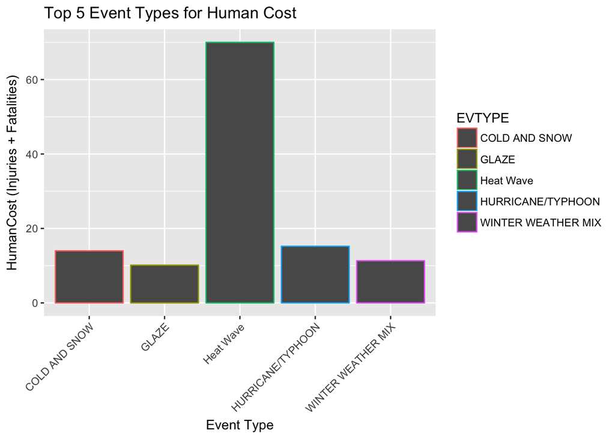

```r
par(mfrow = c(2,1))
p1 <- ggplot(EventHumanCost, aes(x = EVTYPE, y = HumanCost, colour = EVTYPE))
p1 <- p1 + geom_bar(stat = "identity")
p1 <- p1 + theme(axis.text.x = element_text(angle = 45, hjust = 1))
p1 <- p1 + ggtitle("Top 5 Event Types for Human Cost")
p1 <- p1 + xlab("Event Type") + ylab("HumanCost (Injuries + Fatalities)")
print(p1)
```

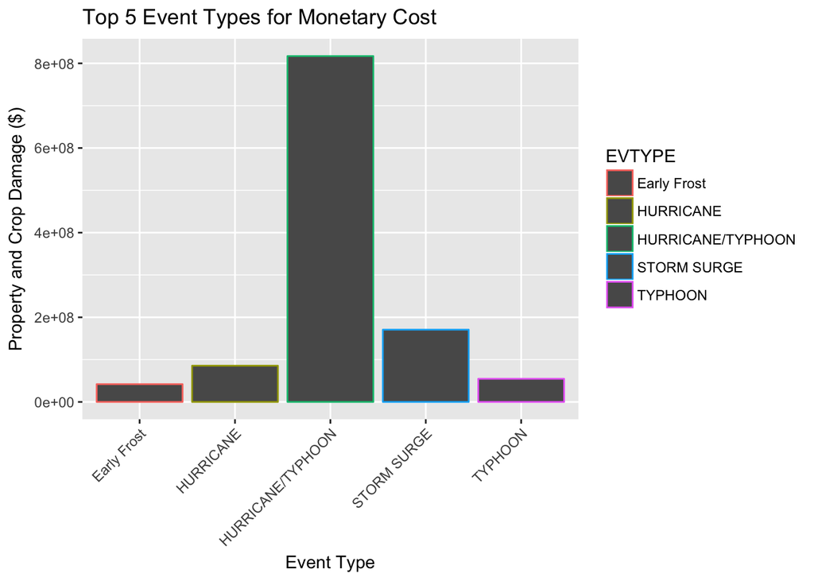

```r
p2 <- ggplot(EventPropertyCost, aes(x=EVTYPE, y = DamageCost, colour = EVTYPE))
p2 <- p2 + geom_bar(stat = "identity")
p2 <- p2 + theme(axis.text.x = element_text(angle = 45, hjust = 1))
p2 <- p2 + ggtitle("Top 5 Event Types for Monetary Cost")
p2 <- p2 + xlab("Event Type") + ylab("Property and Crop Damage ($)")
print(p2)
```

# Results

The above analysis yields intersting results in figuring out which event types cost the American public more in terms of human life and cost of destruction of property and crops.

## Human Cost

Based on our simple metric for calculating human cost, we can see that heat waves are the deadliest of American weather events on average by a factor of over 3. While our decision to only look at the top 5 for each class of damage may be short-sighted and cause us to miss some patterns, we can at least see this clearly. This event type is followed by hurricane/typhoon, and then cold and snow.

## Property Cost

This class of cost showed similarly an event type which resoundingly held the top position with an average of just over $817.2m in lost property and crops per hurricane/typhoon. Following next is the storm surge event type which on average cost 4.79 times less than hurricanes/typhoons. Interestingly enough, the following two event types are hurricane and then typhoon. This means there may have been a potential data cleansing step missed, and calls for an additional study to explore this.